# Coursework I - Capital Bikeshare Data Analysis

# 1 Introduction

This notebook contains the analysis of bike rides undertaken by users of Capital Bikeshare (CaBi), which is a publicly-owned bicycle sharing system that serves areas in and around Washington DC in the United States.

This covers data taken between January 2019 and July 2020 inclusive.

This dataset is worth studying to identify, for example, how popular the service is, how long an average ride is, what stations are the most popular (and therefore crowded!) and if there are any seasonal or time patterns correlated to general use.

The questions that have been selected for investigation are reported in the “Questions” section.

# 2 Data

The data was publicly available on the [website](https://www.capitalbikeshare.com/system-data) of the company, encoded as zipped CSV files, one for each month, for a total of 19 files. They were subsequently imported and the tables joined together by row.

The resulting data frame (as tibble) contained 4,602,349 observations, each corresponding to a single ride. The naming convention for columns changed at one point in time; therefore, columns that contained the same data (start station, end station, start time, end time and membership type) had to be merged and named according to snake_case convention.

Some of the columns(variables) were eliminated, as they were not used for the analysis; the final, clean dataset is called `rides_clean`. A subset of the rows(observations) that contained latitude and longitude values for the start and end stations was extracted from `rides_clean` and named `rides_clean_latlng`.

The variables in the `rides_clean_latlng` tibble were:

- `duration` : the length of the rides in seconds;
- `started_at`: the starting date and time-of-day of the rides;
- `ended_at`: the finishing date and time-of-day of the rides;
- `start_station_name`: the name of the start station;
- `end_station_name`: the name of the finishing station;
- `member_casual`: the membership type of the user;
- `start_lat`: latitude of the starting station;
- `start_lng`: longitude of the starting station;
- `end_lat`: latitude of the ending station;
- `end_lng`: longitude of the ending station;
- `lat_diff`: difference in latitude between end and start stations (calculated);
- `lng_diff`: difference in latitude between end and start stations (calculated)

The variables in `rides_clean` are the same, minus the last 6 columns above.

The rows were then filtered to remove all rides that lasted less than 60 seconds, and initially, all of the rides that lasted longer than 24 hours. The first condition stems from the fact that, as stated on the company website

> This data has been processed to remove trips that are taken by staff as they service and inspect the system, trips that are taken to/from any of our “test” stations at our warehouses and **any trips lasting less than 60 seconds (potentially false starts or users trying to re-dock a bike to ensure it’s secure)**.

The second condition is an initial sanity check to avoid counting bikes that have been probably abandoned or docked incorrectly. This value will be further refined depending on the initial data visualisation.

# 3 Questions

The following questions have been chosen for exploration:

1. How long are bike rides, and are there any differences between casual users and members?
2. In what months were most of the rides taken?
3. Is duration correlated to distance?
4. What are the most popular start and end stations?
5. What time of the day are most of the rides taken, and what is their duration?

Data visualisation that attempts to answer each question will be explored in its own section.

# 4 Analysis

## 4.1 How long are bike rides, and are there any differences between casual users and members?

**Operationalisation**: use histograms to visualise the distribution of ride durations, divided into facets by user type (member or casual user)

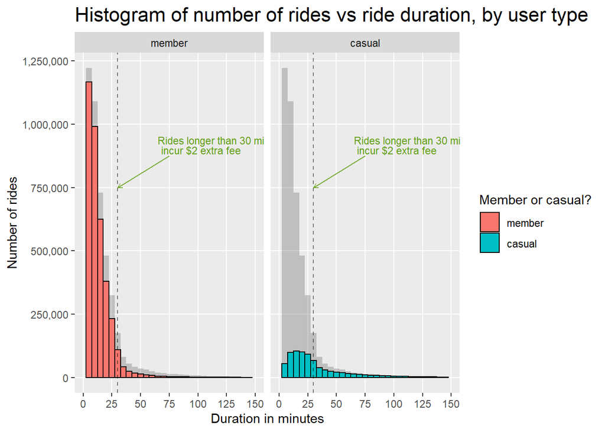

## 4.2 In what months were most of the rides taken?

**Operationalisation**: plot the number of rides against the time of the year (month and year), divided by user type, using a bar chart. A stacked representation has been chosen to highlight the overall numbers.

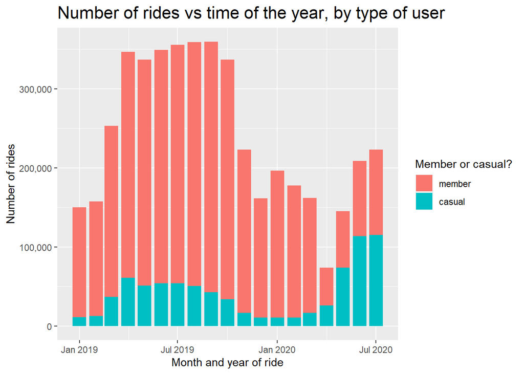

We can notice how bike rides peaked from Apr to Oct 2019, when the weather is warmer. There was still a rising trend in 2020, but the Covid lockdown in Apr 2020 led to a decrease in the number of users when compared to the same month in 2019. Interestingly, the proportion of casual users increased, which is probably due to the fact that the uncertainty related to Covid made it more attractive to use bikes instead of public transport (eg. metro or bus), but without the need for necessarily committing to a membership.

## 4.3 Is duration correlated to distance?

**Operationalisation**: by plotting a scatterplot of the differences between the start_lat and end_lat, and the start_long and end_long of bike rides, and mapping colour to duration, we can observe whether there is a relationship between distance between the stations and duration of the ride. Since the area of Washington DC is small compared to the area of the Earth, the difference between latitudes and longitudes is taken as a proxy of the distance, as we can ignore the curvature of the Earth.

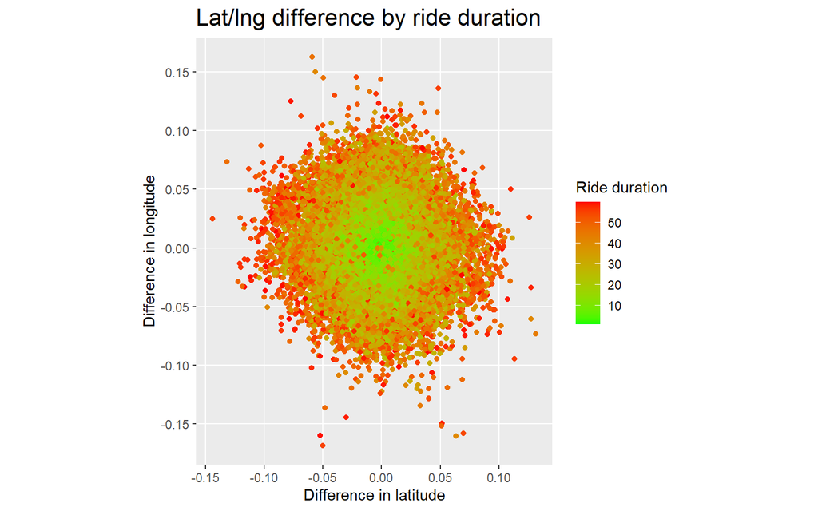

As the plot clearly shows, there is a relationship between the difference in longitude and latitude, and the duration of a ride. There also seems to be a relatively symmetrical distribution of rides, with approximately as many rides in the N-S direction(from -0.1 to 0.1 latitude difference) as in the W-E direction (again, from -0.1 to 0.1).

## 4.4 What are the most popular start and end stations?

**Operationalisation**: column chart of the top 10 stations, ordered from highest to lowest number of rides, for both start and end stations.

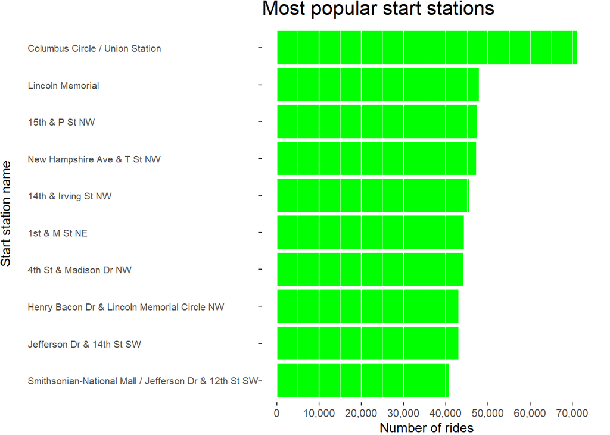

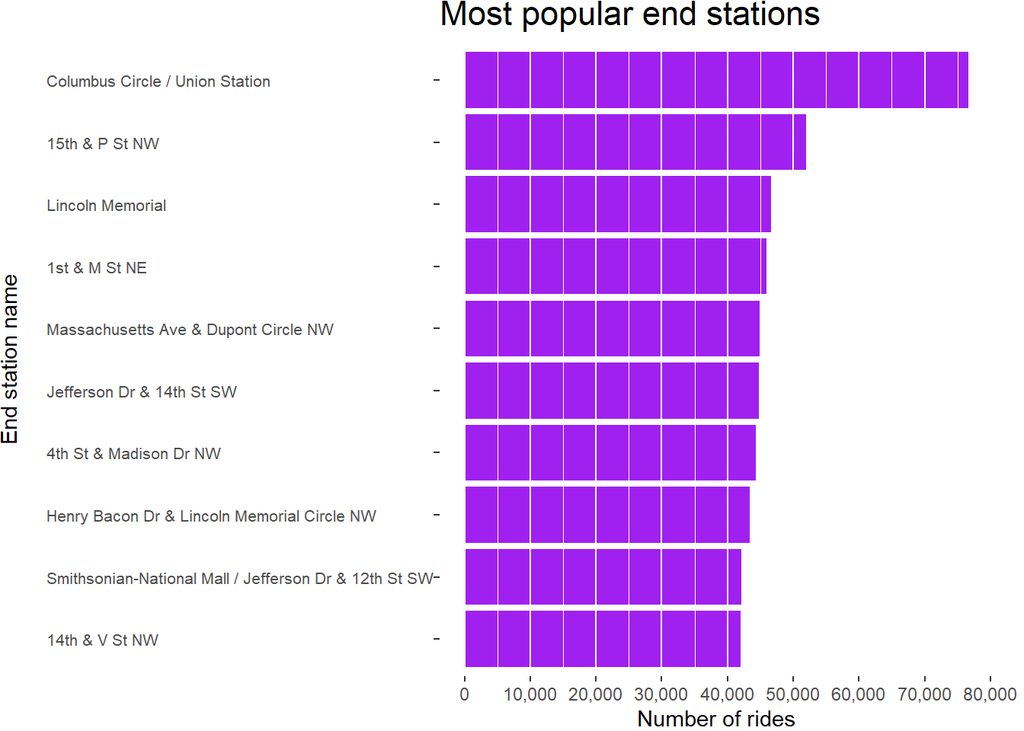

Albeit with slightly different ranking, it can be seen that the most popular start and end stations largely match, with *Columbus Circle/Union Station* and the *Lincoln Memorial* being the most popular. New Hampshire Ave & T St NW is the 4th start station by number of rides, but it is not in the top 10 end stations. On the other hand, the Massachusetts Ave & Dupont Circle NW is 5th in the most popular end stations, but not in the top 10 start stations.

## 4.5 What time of the day are most of the rides taken, and what is their duration?

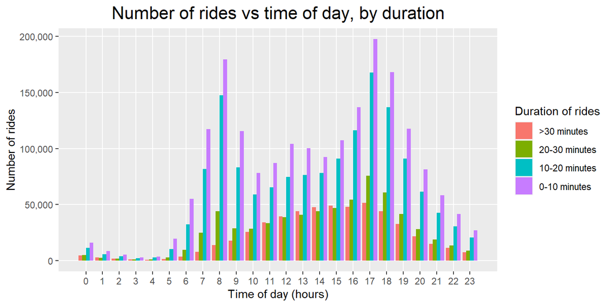

It can be easily observed how most of the rides (threshold for “most” defined as >50,000 for 0-10 minutes) occurred from 6AM till 9PM. For short trips of 0-10 minutes, there were two distinctive peaks at 8AM and 5PM, which match the time most people go to work and leave the workplace. This trend becomes less visible for rides of longer duration, and disappears entirely for rides that lasted longer than 30 minutes, suggesting that people who rode for longer were doing it for leisure and not for work purposes.

# 5 Conclusions

Analysis of this dataset has revealed that most users of the Capital BikeShare service have some form of membership, and that the service is largely used by commuters. Most rides last between 0-10 minutes for members and 10-20 minutes for casual users. The majority of rides occurred between Apr 2019 and Oct 2019. Covid-19 has had a measurable impact on the numbers when compared month-on-month since Apr 2020 (~ 350,000 in Apr 2019 vs ~ 75,000 in Apr 2020). There seems not to be a preferential direction for rides, with roughly as many people riding in one direction, as those travelling the opposite way. The most popular station (for both start and end) is Columbus Circle/Union Station.

An interesting question, raised by the analysis of the second point, is whether the recent trend of increasing casual users will continue over time, and if this will lead to prices being adjusted to make membership more attractive (or casual use more expensive).